In many statistical analysis Anova is the prefer method of statistical analysis which we are testing the difference between one variable factor levels. There are three commonly used of Anova Method.

- One Way Anova
- Two Way Anova
- N Way Anova

One way Anova is a hypothesis testing methodology that is used to test hypothesis on variance of a giving population. The test is normally performed on the factor level of a variable against the independent variable. For example a data set with two variables one variable contains the factor level such as male and female, and the independent variable is the variable that contains a continuous variable such as salary.

One way Anova is based on the following assumptions:

- Normal distribution of the population from which the samples are drawn.
- Measurement of the dependent variable is at interval or ratio level.
- Two or more than two categorical independent groups in an independent variable.
- Independence of samples
- Homogeneity of the variance of the population.

To begin exploring Analysis of Variance I will use the data found in the below website: A full version of the dataset diet may be found online on the U. of Sheffield website https://www.sheffield.ac.uk/polopoly_fs/1.570199!/file/stcp-Rdataset-Diet.csv.

After downloading the dataset, I have placed it in my datasources folder where I am going to source the data from.

TO be able to use it with R I have set this datasource folder as my working directory.

Lets begin the data analysis shall we.

```r
library(dplyr)
library(ggplot2)
library(kableExtra)
```

Lets Import the data set into R.

```r
df = read.csv("D:\\Emman\\Documents\\GitHub\\MaderaAnalytics\\MaderaAnalytics\\MaderaAnalytics\\DataSources\\diet.csv")

kable(head(df), format='markdown')
```

| Person | gender | Age | Height | pre.weight | Diet | weight6weeks |
| --- | --- | --- | --- | --- | --- | --- |
| 25 | NA | 41 | 171 | 60 | 2 | 60.0 |
| 26 | NA | 32 | 174 | 103 | 2 | 103.0 |
| 1 | 0 | 22 | 159 | 58 | 1 | 54.2 |
| 2 | 0 | 46 | 192 | 60 | 1 | 54.0 |
| 3 | 0 | 55 | 170 | 64 | 1 | 63.3 |
| 4 | 0 | 33 | 171 | 64 | 1 | 61.1 |

Our first step is to clean the dataset and get this data set for ANOVA Analysis.

Lets view the structure of the data.

```r
str(df)
```

```
## 'data.frame':    78 obs. of  7 variables:
##  $ Person      : int  25 26 1 2 3 4 5 6 7 8 ...
##  $ gender      : int  NA NA 0 0 0 0 0 0 0 0 ...
##  $ Age         : int  41 32 22 46 55 33 50 50 37 28 ...
##  $ Height      : int  171 174 159 192 170 171 170 201 174 176 ...
##  $ pre.weight  : int  60 103 58 60 64 64 65 66 67 69 ...
##  $ Diet        : int  2 2 1 1 1 1 1 1 1 1 ...
##  $ weight6weeks: num  60 103 54.2 54 63.3 61.1 62.2 64 65 60.5 ...
```

Right of the bat we can see from the structure of the data that there are NULL values in the gender variable. Also, the diet variable is the treatment variable. We need to convert both the gender vairable and diet variable as factors.

We will also replace the the null values with 1 in the Gender field.

```r
df$Diet = factor(df$Diet)

df$gender = ifelse(is.na(df$gender), 1, df$gender) %>% factor()

str(df)
```

```
## 'data.frame':    78 obs. of  7 variables:
##  $ Person      : int  25 26 1 2 3 4 5 6 7 8 ...
##  $ gender      : Factor w/ 2 levels "0","1": 2 2 1 1 1 1 1 1 1 1 ...
##  $ Age         : int  41 32 22 46 55 33 50 50 37 28 ...
##  $ Height      : int  171 174 159 192 170 171 170 201 174 176 ...
##  $ pre.weight  : int  60 103 58 60 64 64 65 66 67 69 ...
##  $ Diet        : Factor w/ 3 levels "1","2","3": 2 2 1 1 1 1 1 1 1 1 ...
##  $ weight6weeks: num  60 103 54.2 54 63.3 61.1 62.2 64 65 60.5 ...
```

Now we will get the difference between initial weight and final weight. This calulaiton will be the final weight in which we will run an ANOVA to determine which diet was the best diet.

```r
df1 = df %>% select(-Person) %>% mutate(weightloss = pre.weight - weight6weeks)

kable(head(df1), format = "markdown")
```

| gender | Age | Height | pre.weight | Diet | weight6weeks | weightloss |
| --- | --- | --- | --- | --- | --- | --- |
| 1 | 41 | 171 | 60 | 2 | 60.0 | 0.0 |
| 1 | 32 | 174 | 103 | 2 | 103.0 | 0.0 |
| 0 | 22 | 159 | 58 | 1 | 54.2 | 3.8 |
| 0 | 46 | 192 | 60 | 1 | 54.0 | 6.0 |
| 0 | 55 | 170 | 64 | 1 | 63.3 | 0.7 |
| 0 | 33 | 171 | 64 | 1 | 61.1 | 2.9 |

Lets visualize the relationship between weightloss and Diet in a boxplot.

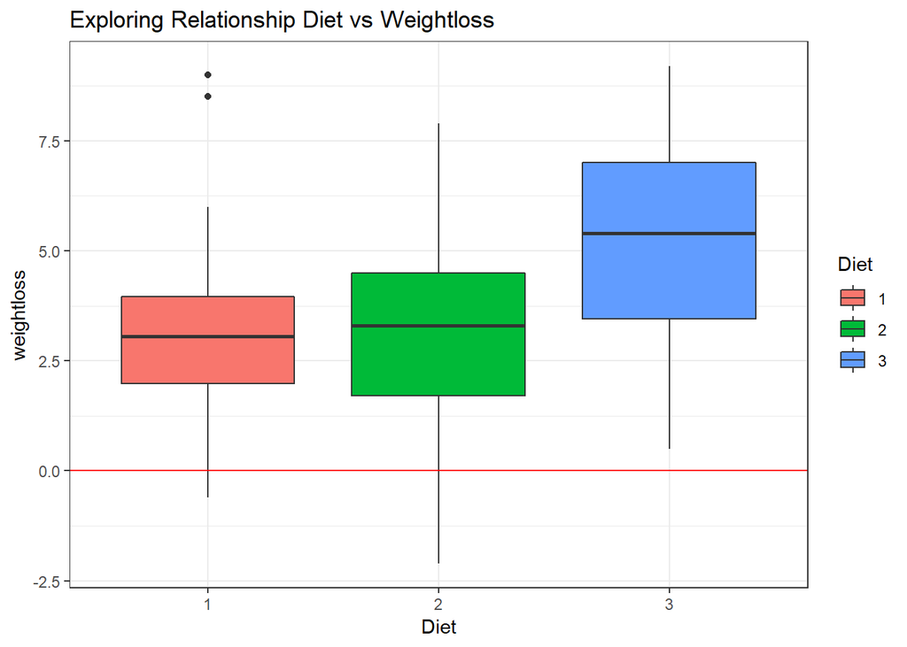

```r
ggplot(df1, aes(Diet, weightloss, fill = Diet)) +
    geom_boxplot() +
    geom_hline(yintercept = 0, color = "red") +
    ggtitle("Exploring Relationship Diet vs Weightloss") +
    theme_bw()
```

After visualizing where the mean of the weightloss fall using a boxplot we can see that for Diet 1 there are two outliers.  
THis is fine there are not extreme observation as the data set is too small. Visually we can see that diet 3 has the greatest mean between the groups.

#### Hypothesis

Four our hypothesis testing of this analysis of variance our:

- H0: All groups have equal means.
- Ha: Not all groups have equal means.

# One Way Anova

Lets use the aov() to compare the means between the groups. We can also visualize the results using a post hoc test with the tukeyHSD() function.

Our formula for a one way anova is as follows:

formalula = Weightloss ~ Diet

```r
model = aov(weightloss ~ Diet, data = df1)

summary(model)
```

```
##             Df Sum Sq Mean Sq F value  Pr(>F)
## Diet         2   71.1   35.55   6.197 0.00323 **
## Residuals   75  430.2    5.74
## ---
## Signif. codes:  0 '***' 0.001 '**' 0.01 '*' 0.05 '.' 0.1 ' ' 1
```

Since got the model we can access the residuals and plot the results to see the actual variations of the group.

```r
df1$resid = model$residuals

kable(head(df1), format="markdown")
```

| gender | Age | Height | pre.weight | Diet | weight6weeks | weightloss | resid |
| --- | --- | --- | --- | --- | --- | --- | --- |
| 1 | 41 | 171 | 60 | 2 | 60.0 | 0.0 | -3.025926 |
| 1 | 32 | 174 | 103 | 2 | 103.0 | 0.0 | -3.025926 |
| 0 | 22 | 159 | 58 | 1 | 54.2 | 3.8 | 0.500000 |
| 0 | 46 | 192 | 60 | 1 | 54.0 | 6.0 | 2.700000 |
| 0 | 55 | 170 | 64 | 1 | 63.3 | 0.7 | -2.600000 |
| 0 | 33 | 171 | 64 | 1 | 61.1 | 2.9 | -0.400000 |

Lets plot the residual on a boxplot to see the difference of means using the residuals.

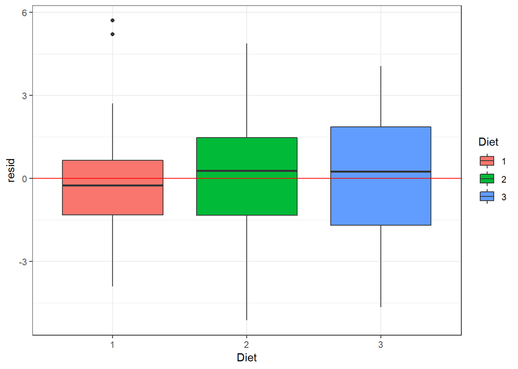

```r
ggplot(df1, aes(Diet, resid, fill = Diet)) +
    geom_boxplot() +
    geom_hline(yintercept = 0, color = "red") +
    theme_bw()
```

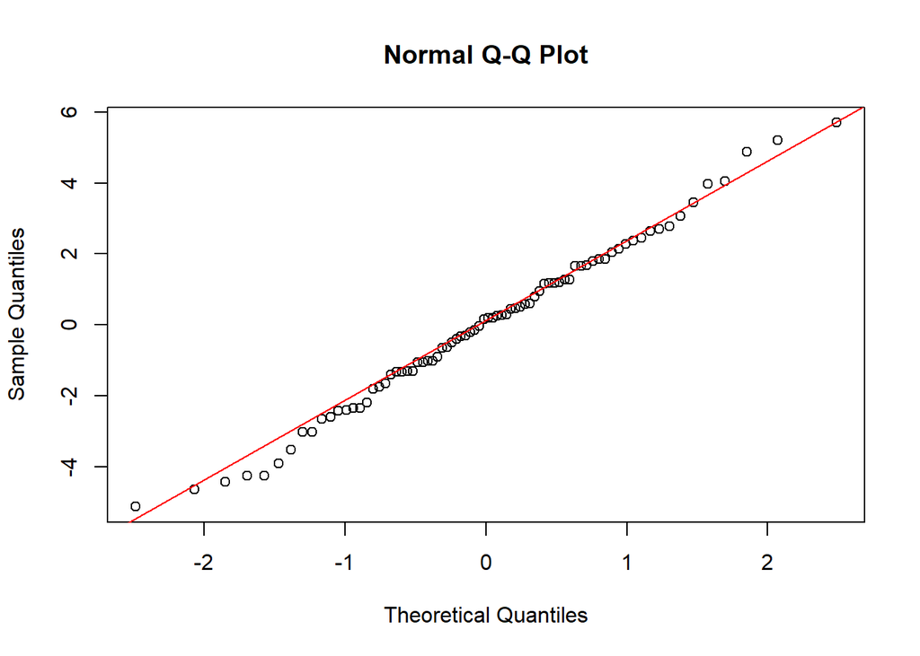

```r
qqnorm(df1$resid)
qqline(df1$resid, col = "red")
```

```r
pairwise = TukeyHSD(model)
pairwise
```

```
##   Tukey multiple comparisons of means
##     95% family-wise confidence level
##
## Fit: aov(formula = weightloss ~ Diet, data = df1)
##
## $Diet
##           diff        lwr      upr     p adj
## 2-1 -0.2740741 -1.8806155 1.332467 0.9124737
## 3-1  1.8481481  0.2416067 3.454690 0.0201413
## 3-2  2.1222222  0.5636481 3.680796 0.0047819
```

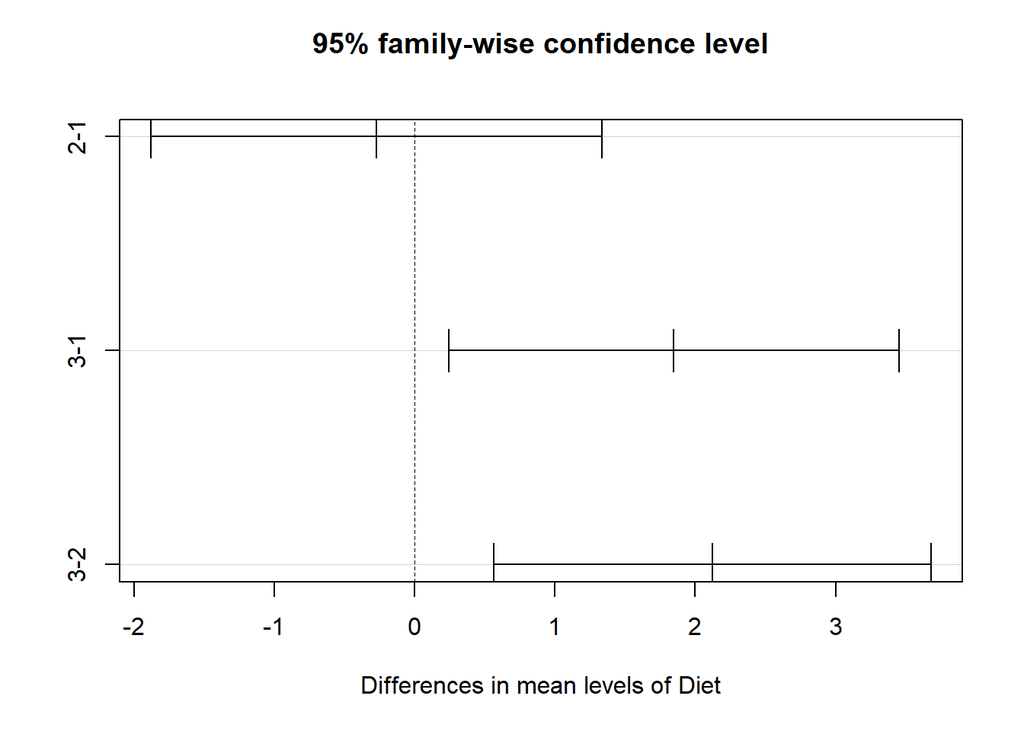

```r
plot(pairwise)
```

## References:

Two-Way ANOVA Test in R - Easy Guides - Wiki - STHDA Two-Way ANOVA Test in R - Easy Guides - Wiki - STHDA. (2018). Sthda.com. Retrieved 6 October 2018, from http://www.sthda.com/english/wiki/two-way-anova-test-in-r

Pasin, M. and profile, V. Pasin, M., & profile, V. (2014). Performing ANOVA Test in R: Results and Interpretation. Analyticsforfun.com. Retrieved 6 October 2018, from http://www.analyticsforfun.com/2014/06/performing-anova-test-in-r-results-and.html